# Homework 1

Group 2

02/27/2019

# Part 1: Overview

The purpose of this assignment is to explore, analyze and model professional baseball team performance from the years 1871 to 2006. Our objective is to build a multiple linear regression model on the provided data to predict the number of wins for the team.**

## Dependencies

Replication of our work requires the following dependencies:

```r
library(dplyr)
library(tidyr)
library(ggplot2)
library(car)
library(corrplot)
library(Hmisc)
library(psych)
library (MASS)
library(lmtest)
library(faraway)
library(knitr)
library(kableExtra)
```

## Data Preparation

We first read the training and test data from the csv files located in our repository.

```r
train_data <- "moneyball-training-data.csv"
test_data <- "moneyball-evaluation-data.csv"
moneyball_data <- read.csv(train_data, header=TRUE, stringsAsFactors=FALSE, fileEncoding="latin1")
test_data <- read.csv(test_data, header = TRUE, stringsAsFactors = FALSE)
```

# Part 2: Data Exploration

Upon review of the dataset, we found large amounts of missing variables. We choose to replace the empty data points with the mean of that data column. The method was preferable to removing the data with omitted values, because that would have removed 90% of the provided data.

We calculated the appropriate means to compensate for the incomplete data below:

```r
sapply(moneyball_data, function(y) sum(length(which(is.na(y)))))/nrow(moneyball_data)*100
```

```
##            INDEX      TARGET_WINS   TEAM_BATTING_H  TEAM_BATTING_2B
##         0.000000         0.000000         0.000000         0.000000
##  TEAM_BATTING_3B  TEAM_BATTING_HR  TEAM_BATTING_BB  TEAM_BATTING_SO
##         0.000000         0.000000         0.000000         4.481547
##  TEAM_BASERUN_SB  TEAM_BASERUN_CS TEAM_BATTING_HBP  TEAM_PITCHING_H
##         5.755712        33.919156        91.608084         0.000000
## TEAM_PITCHING_HR TEAM_PITCHING_BB TEAM_PITCHING_SO  TEAM_FIELDING_E
##         0.000000         0.000000         4.481547         0.000000
## TEAM_FIELDING_DP
##        12.565905
```

```r
sapply(test_data, function(y) sum(length(which(is.na(y)))))/nrow(moneyball_data)*100
```

```
##            INDEX   TEAM_BATTING_H  TEAM_BATTING_2B  TEAM_BATTING_3B
##        0.0000000        0.0000000        0.0000000        0.0000000
##  TEAM_BATTING_HR  TEAM_BATTING_BB  TEAM_BATTING_SO  TEAM_BASERUN_SB
##        0.0000000        0.0000000        0.7908612        0.5711775
##  TEAM_BASERUN_CS TEAM_BATTING_HBP  TEAM_PITCHING_H TEAM_PITCHING_HR
##        3.8224956       10.5448155        0.0000000        0.0000000
## TEAM_PITCHING_BB TEAM_PITCHING_SO  TEAM_FIELDING_E TEAM_FIELDING_DP
##        0.0000000        0.7908612        0.0000000        1.3620387
```

We also choose to removed “index” and “TEAM_BATTING_HBP” columns as “TEAM_BATTING_HBP” has 92% of missing values" and “index” was just a counter.

```r
moneyball_data<-subset(moneyball_data, select = -c(INDEX))
moneyball<-subset(moneyball_data, select = -c(TEAM_BATTING_HBP))

test_data <- subset(test_data, select = -c(INDEX))
test_data <- subset(test_data, select = -c(TEAM_BATTING_HBP))
```

## Summary Statistics

Through these steps, we replaced the missing data with the appropriate mean data.

```r
replace_mean <- function(x){
  x <- as.numeric(as.character(x))
  x[is.na(x)] = mean(x, na.rm=TRUE)
  return(x)
}

moneyball_filled <- apply(moneyball, 2, replace_mean)
moneyball_filled <- as.data.frame(moneyball_filled)

test_filled <- apply(test_data, 2, replace_mean)
test_filled <- as.data.frame(test_data)
```

| TEAM_BATTING_H | 1469.3900 |
| --- | --- |
| TEAM_BATTING_2B | 241.3205 |
| TEAM_BATTING_3B | 55.9112 |
| TEAM_BATTING_HR | 95.6332 |
| TEAM_BATTING_BB | 498.9575 |
| TEAM_BATTING_SO | NA |
| TEAM_BASERUN_SB | NA |
| TEAM_BASERUN_CS | NA |
| TEAM_PITCHING_H | 1813.4633 |
| TEAM_PITCHING_HR | 102.1467 |
| TEAM_PITCHING_BB | 552.4170 |
| TEAM_PITCHING_SO | NA |
| TEAM_FIELDING_E | 249.7490 |
| TEAM_FIELDING_DP | NA |

### Histogram

Now that we have a ‘good’ dataset, we can look at some histograms for each data vector. Our output suggests that most variables are fairly normally distributed and span many orders of magnitude. This tells us that our model will have some kind scaling factor between our data vectors.

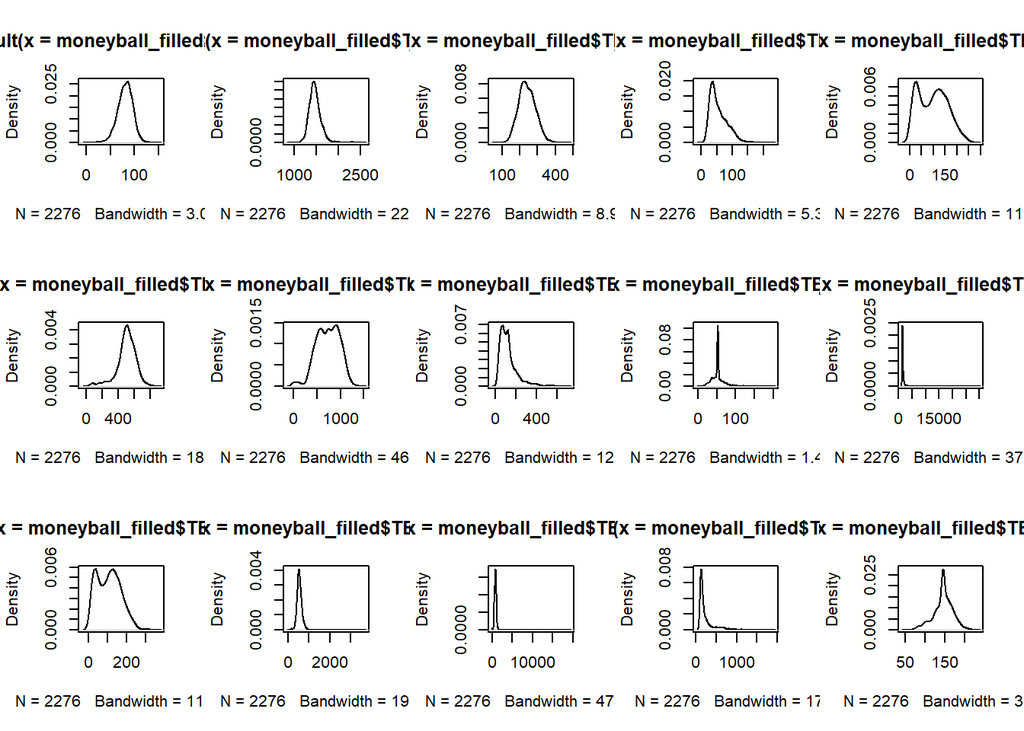

### Target Wins Variable

To better understand the goal of our model, we examined the targeted wins variable. Below are the plots that show this variable follows a normal, unimodal distribution that is slightly skewed to the left.

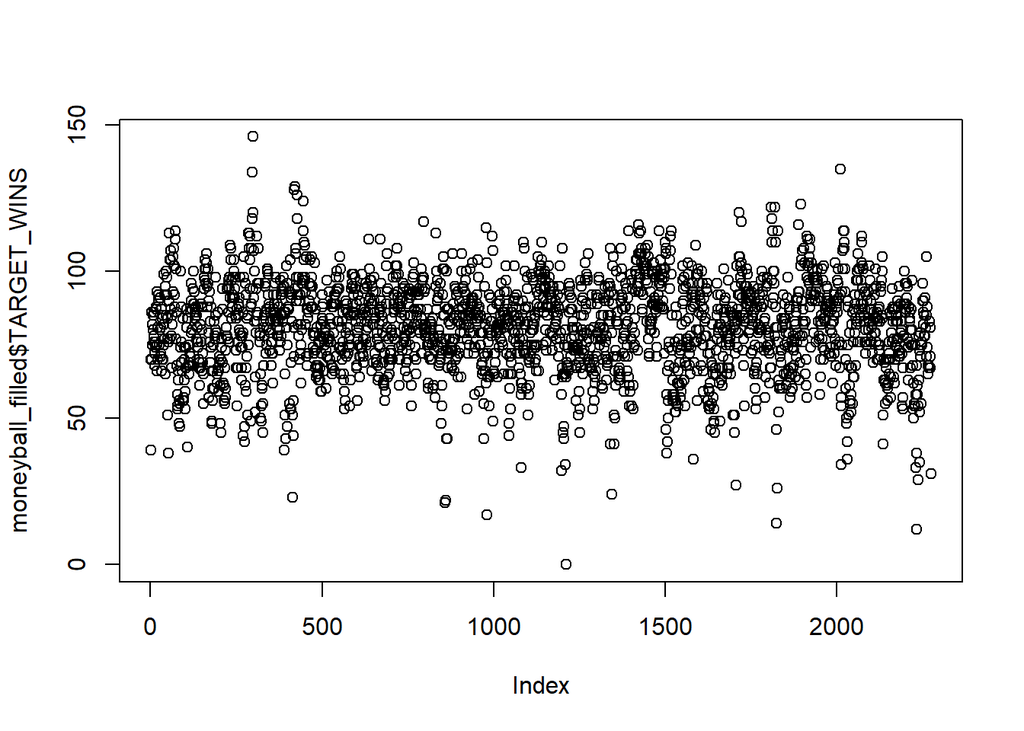

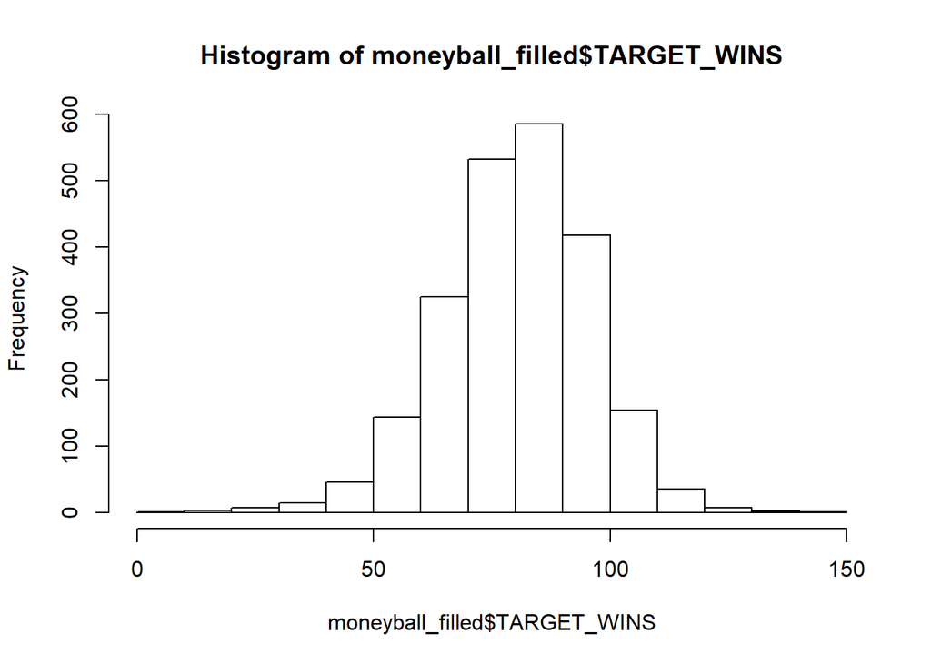

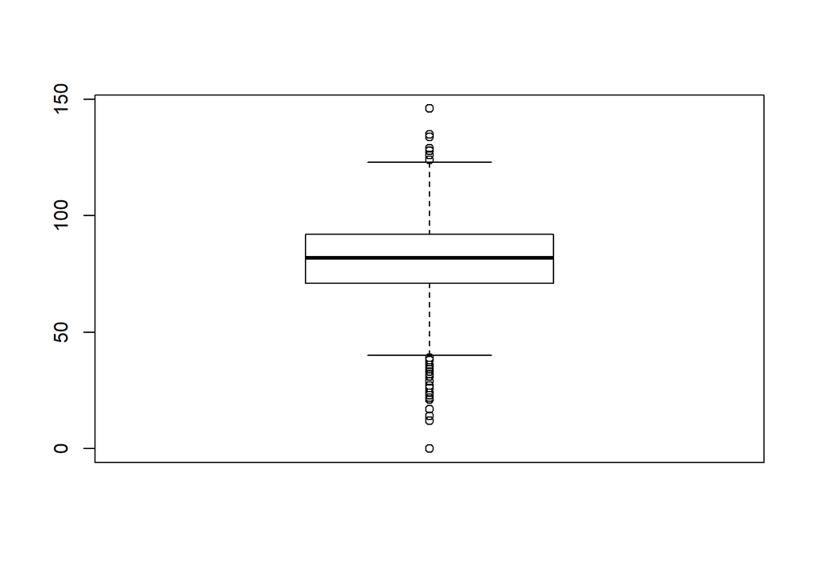

```
##    Min. 1st Qu.  Median    Mean 3rd Qu.    Max.
##    0.00   71.00   82.00   80.79   92.00  146.00
```

## Correlation

We then checked for correlation among our dependent variables, as all variables are numeric we will rely on correlation. Below is a correlation plot that highlights the correlation between various data vectors. Dark blue is a high, positive correlation and dark red is a large negative correlation.

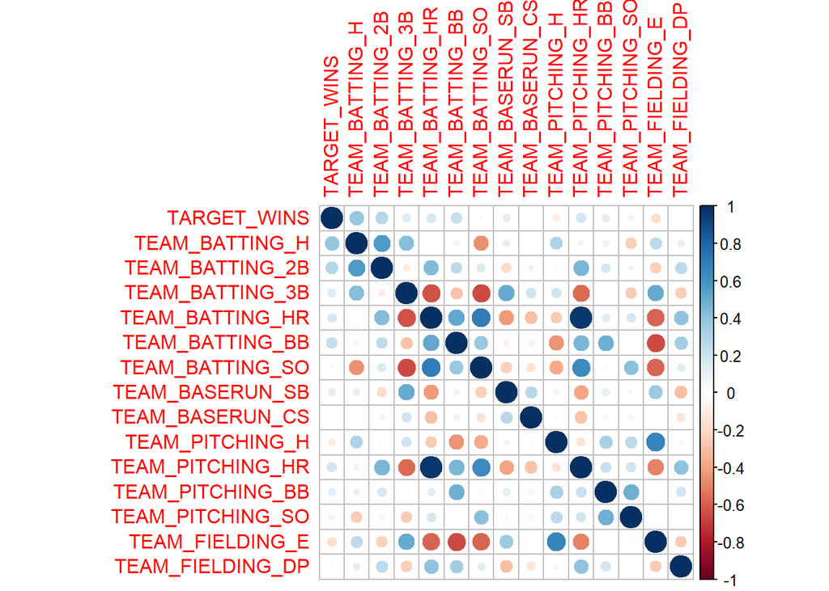

Here, we notice several variables have poor correlation with the target variable (p<0.1):  
- `TEAM_FIELDING_E`  
- `TEAM_BASERUN_CS`  
- `TEAM_BATTING_SO`  
- `TEAM_BATTING_3B`

However, others have strong correlation between each others (>0.6):  
- `TEAM_PITCHING_HR` vs `TEAM_BATTING_HR` (0.969)  
- `TEAM_BATTING_HR` vs `TEAM_BATTING_SO` (0.693)  
- `TEAM_BATTING_3B` vs `TEAM_BATTING_SO` (-0.656)

Due to co-linearity or statistical irrelevance, we can remove: `TEAM_FIELDING_E`, `TEAM_BASERUN_CS`, `TEAM_BATTING_SO`, `TEAM_BATTING_3B`, and `TEAM_BATTING_HR`.

# Part 3: Modeling

We started with a naive model that uses all of the data vectors. We got an adjusted $R^2$ value of 31.4%.

```
##
## Call:
## lm(formula = TARGET_WINS ~ TEAM_BATTING_H + TEAM_BATTING_2B +
##     TEAM_BATTING_3B + TEAM_BATTING_HR + TEAM_BATTING_BB + TEAM_BATTING_SO +
##     TEAM_BASERUN_SB + TEAM_BASERUN_CS + TEAM_PITCHING_H + TEAM_PITCHING_HR +
##     TEAM_PITCHING_BB + TEAM_PITCHING_SO + TEAM_FIELDING_E + TEAM_FIELDING_DP,
##     data = moneyball_filled)
##
## Residuals:
##     Min      1Q  Median      3Q     Max
## -49.994  -8.576   0.136   8.345  58.628
##
## Coefficients:
##                    Estimate Std. Error t value Pr(>|t|)
## (Intercept)       2.502e+01  5.397e+00   4.636 3.75e-06 ***
## TEAM_BATTING_H    4.824e-02  3.687e-03  13.085  < 2e-16 ***
## TEAM_BATTING_2B  -2.006e-02  9.152e-03  -2.192 0.028486 *
## TEAM_BATTING_3B   6.047e-02  1.676e-02   3.608 0.000315 ***
## TEAM_BATTING_HR   5.299e-02  2.743e-02   1.932 0.053488 .
## TEAM_BATTING_BB   1.042e-02  5.818e-03   1.790 0.073544 .
## TEAM_BATTING_SO  -9.349e-03  2.551e-03  -3.665 0.000253 ***
## TEAM_BASERUN_SB   2.949e-02  4.462e-03   6.610 4.78e-11 ***
## TEAM_BASERUN_CS  -1.188e-02  1.614e-02  -0.736 0.461905
## TEAM_PITCHING_H  -7.342e-04  3.676e-04  -1.997 0.045946 *
## TEAM_PITCHING_HR  1.480e-02  2.432e-02   0.609 0.542877
## TEAM_PITCHING_BB  8.891e-05  4.145e-03   0.021 0.982891
## TEAM_PITCHING_SO  2.843e-03  9.187e-04   3.095 0.001994 **
## TEAM_FIELDING_E  -2.112e-02  2.480e-03  -8.516  < 2e-16 ***
## TEAM_FIELDING_DP -1.210e-01  1.302e-02  -9.297  < 2e-16 ***
## ---
## Signif. codes:  0 '***' 0.001 '**' 0.01 '*' 0.05 '.' 0.1 ' ' 1
##
## Residual standard error: 13.04 on 2261 degrees of freedom
## Multiple R-squared:  0.3189, Adjusted R-squared:  0.3147
## F-statistic: 75.63 on 14 and 2261 DF,  p-value: < 2.2e-16
```

Then, we removed the least significant variable, `TEAM_PITCHING_BB`. This yielded a slight increase in our $R^2$ score at 31.5%.

```
##
## Call:
## lm(formula = TARGET_WINS ~ TEAM_BATTING_H + TEAM_BATTING_2B +
##     TEAM_BATTING_3B + TEAM_BATTING_HR + TEAM_BATTING_BB + TEAM_BATTING_SO +
##     TEAM_BASERUN_SB + TEAM_BASERUN_CS + TEAM_PITCHING_H + TEAM_PITCHING_HR +
##     TEAM_PITCHING_SO + TEAM_FIELDING_E + TEAM_FIELDING_DP, data = moneyball_filled)
##
## Residuals:
##     Min      1Q  Median      3Q     Max
## -49.994  -8.576   0.136   8.345  58.626
##
## Coefficients:
##                    Estimate Std. Error t value Pr(>|t|)
## (Intercept)      25.0145796  5.3904993   4.640 3.67e-06 ***
## TEAM_BATTING_H    0.0482393  0.0036807  13.106  < 2e-16 ***
## TEAM_BATTING_2B  -0.0200575  0.0091490  -2.192 0.028457 *
## TEAM_BATTING_3B   0.0604730  0.0167556   3.609 0.000314 ***
## TEAM_BATTING_HR   0.0527106  0.0240710   2.190 0.028641 *
## TEAM_BATTING_BB   0.0105175  0.0033664   3.124 0.001805 **
## TEAM_BATTING_SO  -0.0093631  0.0024585  -3.809 0.000144 ***
## TEAM_BASERUN_SB   0.0295055  0.0044087   6.693 2.76e-11 ***
## TEAM_BASERUN_CS  -0.0118872  0.0161276  -0.737 0.461155
## TEAM_PITCHING_H  -0.0007306  0.0003283  -2.225 0.026147 *
## TEAM_PITCHING_HR  0.0150659  0.0209923   0.718 0.473025
## TEAM_PITCHING_SO  0.0028567  0.0006717   4.253 2.20e-05 ***
## TEAM_FIELDING_E  -0.0211192  0.0024784  -8.521  < 2e-16 ***
## TEAM_FIELDING_DP -0.1210298  0.0130139  -9.300  < 2e-16 ***
## ---
## Signif. codes:  0 '***' 0.001 '**' 0.01 '*' 0.05 '.' 0.1 ' ' 1
##
## Residual standard error: 13.04 on 2262 degrees of freedom
## Multiple R-squared:  0.3189, Adjusted R-squared:  0.315
## F-statistic: 81.49 on 13 and 2262 DF,  p-value: < 2.2e-16
```

We repeated the above procedure for TEAM_BASERUN_CS, netting us a score of 31.52%. By removing two variables we were able to oh-so-slightly increase our $R^2$ value while reducing the amount of data we have to track and the processing time for tracking it.

```
##
## Call:
## lm(formula = TARGET_WINS ~ TEAM_BATTING_H + TEAM_BATTING_2B +
##     TEAM_BATTING_3B + TEAM_BATTING_HR + TEAM_BATTING_BB + TEAM_BATTING_SO +
##     TEAM_BASERUN_SB + TEAM_PITCHING_H + TEAM_PITCHING_HR + TEAM_PITCHING_SO +
##     TEAM_FIELDING_E + TEAM_FIELDING_DP, data = moneyball_filled)
##
## Residuals:
##     Min      1Q  Median      3Q     Max
## -49.905  -8.584   0.124   8.406  58.593
##
## Coefficients:
##                    Estimate Std. Error t value Pr(>|t|)
## (Intercept)      24.2348098  5.2851330   4.585 4.78e-06 ***
## TEAM_BATTING_H    0.0482055  0.0036800  13.099  < 2e-16 ***
## TEAM_BATTING_2B  -0.0203302  0.0091405  -2.224 0.026235 *
## TEAM_BATTING_3B   0.0608466  0.0167463   3.633 0.000286 ***
## TEAM_BATTING_HR   0.0543985  0.0239594   2.270 0.023274 *
## TEAM_BATTING_BB   0.0107643  0.0033494   3.214 0.001328 **
## TEAM_BATTING_SO  -0.0093418  0.0024580  -3.800 0.000148 ***
## TEAM_BASERUN_SB   0.0287600  0.0042906   6.703 2.57e-11 ***
## TEAM_PITCHING_H  -0.0007390  0.0003281  -2.253 0.024372 *
## TEAM_PITCHING_HR  0.0147103  0.0209846   0.701 0.483372
## TEAM_PITCHING_SO  0.0028640  0.0006716   4.265 2.08e-05 ***
## TEAM_FIELDING_E  -0.0207217  0.0024188  -8.567  < 2e-16 ***
## TEAM_FIELDING_DP -0.1211603  0.0130114  -9.312  < 2e-16 ***
## ---
## Signif. codes:  0 '***' 0.001 '**' 0.01 '*' 0.05 '.' 0.1 ' ' 1
##
## Residual standard error: 13.04 on 2263 degrees of freedom
## Multiple R-squared:  0.3188, Adjusted R-squared:  0.3152
## F-statistic: 88.25 on 12 and 2263 DF,  p-value: < 2.2e-16
```

By removing TEAM_PITCHING_HR, we increase our $R^2$ value one last time to 31.53%.

```
##
## Call:
## lm(formula = TARGET_WINS ~ TEAM_BATTING_H + TEAM_BATTING_2B +
##     TEAM_BATTING_3B + TEAM_BATTING_HR + TEAM_BATTING_BB + TEAM_BATTING_SO +
##     TEAM_BASERUN_SB + TEAM_PITCHING_H + TEAM_PITCHING_SO + TEAM_FIELDING_E +
##     TEAM_FIELDING_DP, data = moneyball_filled)
##
## Residuals:
##     Min      1Q  Median      3Q     Max
## -49.899  -8.568   0.091   8.397  58.651
##
## Coefficients:
##                    Estimate Std. Error t value Pr(>|t|)
## (Intercept)      23.6666983  5.2220414   4.532 6.14e-06 ***
## TEAM_BATTING_H    0.0484570  0.0036621  13.232  < 2e-16 ***
## TEAM_BATTING_2B  -0.0205123  0.0091358  -2.245 0.024847 *
## TEAM_BATTING_3B   0.0624661  0.0165843   3.767 0.000170 ***
## TEAM_BATTING_HR   0.0697785  0.0096266   7.249 5.75e-13 ***
## TEAM_BATTING_BB   0.0107446  0.0033489   3.208 0.001354 **
## TEAM_BATTING_SO  -0.0093019  0.0024571  -3.786 0.000157 ***
## TEAM_BASERUN_SB   0.0287708  0.0042901   6.706 2.51e-11 ***
## TEAM_PITCHING_H  -0.0006920  0.0003211  -2.155 0.031253 *
## TEAM_PITCHING_SO  0.0028867  0.0006707   4.304 1.75e-05 ***
## TEAM_FIELDING_E  -0.0205973  0.0024120  -8.540  < 2e-16 ***
## TEAM_FIELDING_DP -0.1210083  0.0130082  -9.302  < 2e-16 ***
## ---
## Signif. codes:  0 '***' 0.001 '**' 0.01 '*' 0.05 '.' 0.1 ' ' 1
##
## Residual standard error: 13.03 on 2264 degrees of freedom
## Multiple R-squared:  0.3186, Adjusted R-squared:  0.3153
## F-statistic: 96.25 on 11 and 2264 DF,  p-value: < 2.2e-16
```

## Checking for non-linearity

Below we use the `crPlots()` function to check for non-linearity.

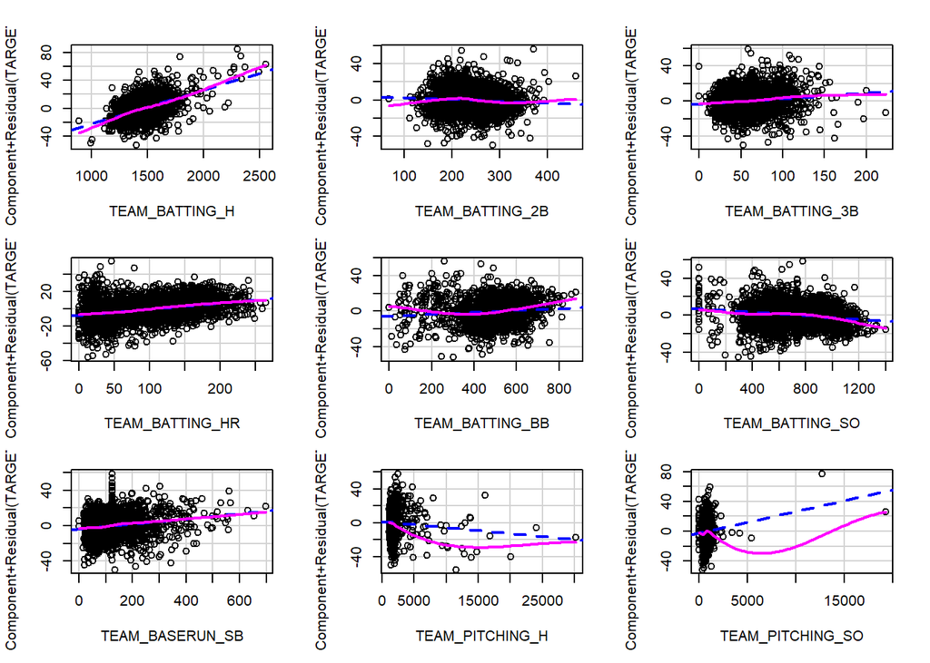

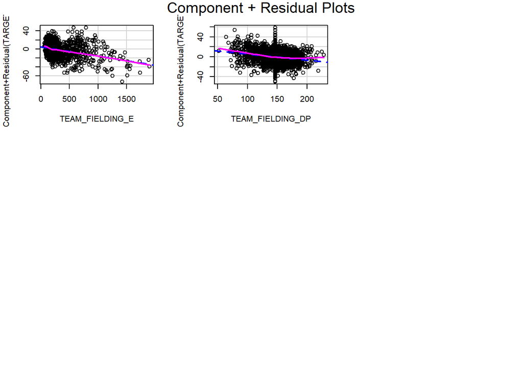

TEAM_PITCHING_H, TEAM_PITCHING_SO did not pass the check for non-linearity. So, we will transform them and refit the model. We are using a log10 transform because these numbers span many orders of magnitude.

```
##
## Call:
## lm(formula = TARGET_WINS ~ TEAM_BATTING_H + TEAM_BATTING_2B +
##     TEAM_BATTING_3B + TEAM_BATTING_HR + TEAM_BATTING_BB + TEAM_BATTING_SO +
##     TEAM_BASERUN_SB + TEAM_PITCHING_H + TEAM_PITCHING_SO + TEAM_FIELDING_E +
##     TEAM_FIELDING_DP, data = moneyball_filled)
##
## Residuals:
##     Min      1Q  Median      3Q     Max
## -53.500  -8.353   0.050   8.276  63.152
##
## Coefficients:
##                    Estimate Std. Error t value Pr(>|t|)
## (Intercept)      -18.385299  13.648651  -1.347 0.178102
## TEAM_BATTING_H     0.041874   0.003784  11.065  < 2e-16 ***
## TEAM_BATTING_2B   -0.020476   0.009106  -2.249 0.024630 *
## TEAM_BATTING_3B    0.087638   0.016862   5.197 2.20e-07 ***
## TEAM_BATTING_HR    0.058540   0.009697   6.037 1.83e-09 ***
## TEAM_BATTING_BB    0.012944   0.003388   3.821 0.000137 ***
## TEAM_BATTING_SO   -0.001186   0.002534  -0.468 0.639742
## TEAM_BASERUN_SB    0.031437   0.004300   7.311 3.65e-13 ***
## TEAM_PITCHING_H   17.140905   4.594173   3.731 0.000195 ***
## TEAM_PITCHING_SO  -2.656620   0.914734  -2.904 0.003717 **
## TEAM_FIELDING_E   -0.030455   0.002954 -10.309  < 2e-16 ***
## TEAM_FIELDING_DP  -0.120505   0.013004  -9.267  < 2e-16 ***
## ---
## Signif. codes:  0 '***' 0.001 '**' 0.01 '*' 0.05 '.' 0.1 ' ' 1
##
## Residual standard error: 13.03 on 2264 degrees of freedom
## Multiple R-squared:  0.319,  Adjusted R-squared:  0.3157
## F-statistic: 96.42 on 11 and 2264 DF,  p-value: < 2.2e-16
```

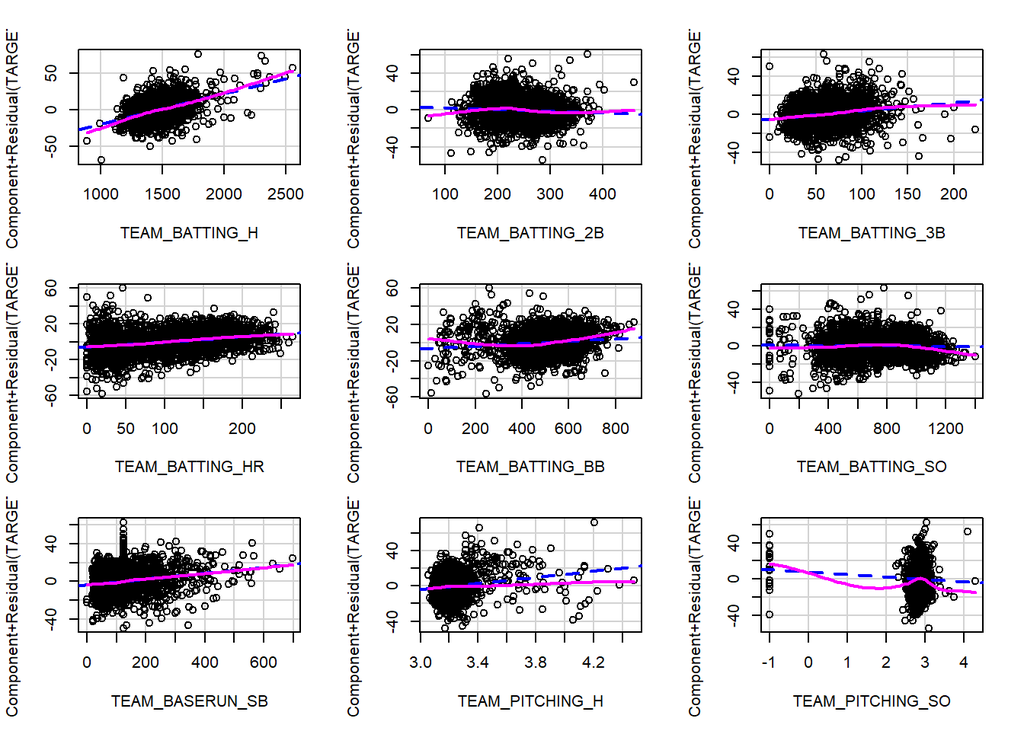

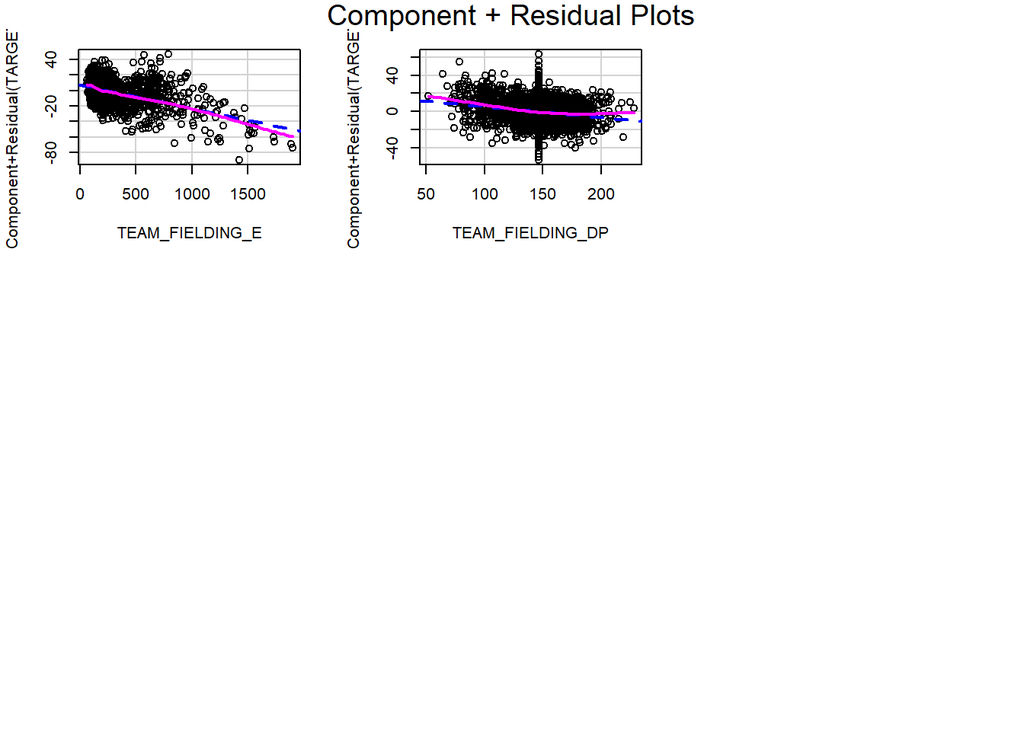

Now we remove `TEAM_BATTING_SO` because it has a p-value > 0.05.

```
##
## Call:
## lm(formula = TARGET_WINS ~ TEAM_BATTING_H + TEAM_BATTING_2B +
##     TEAM_BATTING_3B + TEAM_BATTING_HR + TEAM_BATTING_BB + TEAM_BASERUN_SB +
##     TEAM_PITCHING_H + TEAM_PITCHING_SO + TEAM_FIELDING_E + TEAM_FIELDING_DP,
##     data = moneyball_filled)
##
## Residuals:
##     Min      1Q  Median      3Q     Max
## -53.382  -8.328   0.025   8.211  62.933
##
## Coefficients:
##                    Estimate Std. Error t value Pr(>|t|)
## (Intercept)      -20.516367  12.864856  -1.595 0.110905
## TEAM_BATTING_H     0.042628   0.003424  12.448  < 2e-16 ***
## TEAM_BATTING_2B   -0.021583   0.008792  -2.455 0.014167 *
## TEAM_BATTING_3B    0.089227   0.016513   5.403 7.23e-08 ***
## TEAM_BATTING_HR    0.055774   0.007688   7.255 5.50e-13 ***
## TEAM_BATTING_BB    0.013293   0.003304   4.023 5.93e-05 ***
## TEAM_BASERUN_SB    0.030879   0.004130   7.476 1.09e-13 ***
## TEAM_PITCHING_H   17.440250   4.548668   3.834 0.000129 ***
## TEAM_PITCHING_SO  -2.847123   0.819083  -3.476 0.000519 ***
## TEAM_FIELDING_E   -0.030494   0.002953 -10.328  < 2e-16 ***
## TEAM_FIELDING_DP  -0.119878   0.012932  -9.270  < 2e-16 ***
## ---
## Signif. codes:  0 '***' 0.001 '**' 0.01 '*' 0.05 '.' 0.1 ' ' 1
##
## Residual standard error: 13.03 on 2265 degrees of freedom
## Multiple R-squared:  0.319,  Adjusted R-squared:  0.316
## F-statistic: 106.1 on 10 and 2265 DF,  p-value: < 2.2e-16
```

## Eliminating Outliers

Then, we used Cook’s distance to identify extreme values, removing them as necessary.

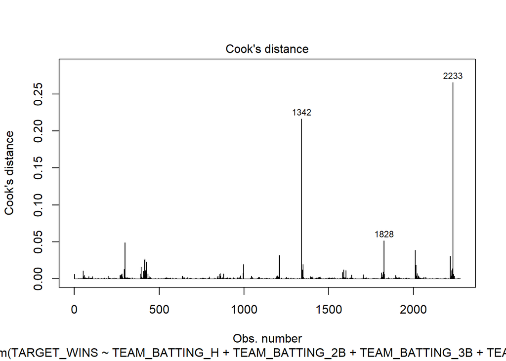

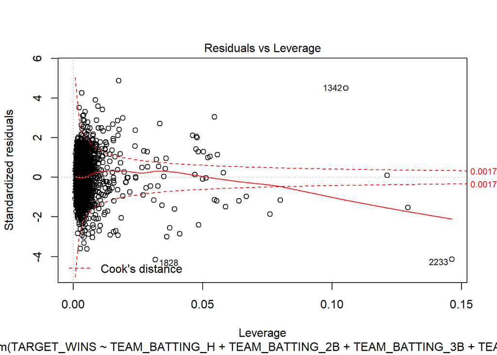

```
##
## Call:
## lm(formula = TARGET_WINS ~ TEAM_BATTING_H + TEAM_BATTING_2B +
##     TEAM_BATTING_3B + TEAM_BATTING_HR + TEAM_BATTING_BB + TEAM_BATTING_SO +
##     TEAM_BASERUN_SB + TEAM_PITCHING_H + TEAM_PITCHING_SO + TEAM_FIELDING_E +
##     TEAM_FIELDING_DP, data = moneyball_filled)
##
## Residuals:
##     Min      1Q  Median      3Q     Max
## -47.117  -8.396   0.026   8.238  64.496
##
## Coefficients:
##                    Estimate Std. Error t value Pr(>|t|)
## (Intercept)      -18.936246  14.300248  -1.324 0.185574
## TEAM_BATTING_H     0.039743   0.003901  10.187  < 2e-16 ***
## TEAM_BATTING_2B   -0.021808   0.009043  -2.412 0.015957 *
## TEAM_BATTING_3B    0.101540   0.016844   6.028 1.93e-09 ***
## TEAM_BATTING_HR    0.065471   0.009640   6.791 1.41e-11 ***
## TEAM_BATTING_BB    0.012322   0.003354   3.674 0.000245 ***
## TEAM_BATTING_SO   -0.001465   0.002507  -0.584 0.559106
## TEAM_BASERUN_SB    0.032302   0.004275   7.556 5.99e-14 ***
## TEAM_PITCHING_H   18.926032   4.961698   3.814 0.000140 ***
## TEAM_PITCHING_SO  -3.560746   0.932952  -3.817 0.000139 ***
## TEAM_FIELDING_E   -0.031367   0.003048 -10.291  < 2e-16 ***
## TEAM_FIELDING_DP  -0.120207   0.012872  -9.339  < 2e-16 ***
## ---
## Signif. codes:  0 '***' 0.001 '**' 0.01 '*' 0.05 '.' 0.1 ' ' 1
##
## Residual standard error: 12.89 on 2261 degrees of freedom
## Multiple R-squared:  0.3245, Adjusted R-squared:  0.3212
## F-statistic: 98.72 on 11 and 2261 DF,  p-value: < 2.2e-16
```

## Checking for Colinearity

```
##   TEAM_BATTING_H  TEAM_BATTING_2B  TEAM_BATTING_3B  TEAM_BATTING_HR
##         4.322088         2.438948         3.007291         4.650721
##  TEAM_BATTING_BB  TEAM_BATTING_SO  TEAM_BASERUN_SB  TEAM_PITCHING_H
##         2.294133         5.045176         1.812464         5.617980
## TEAM_PITCHING_SO  TEAM_FIELDING_E TEAM_FIELDING_DP
##         1.722976         6.490171         1.364366
```

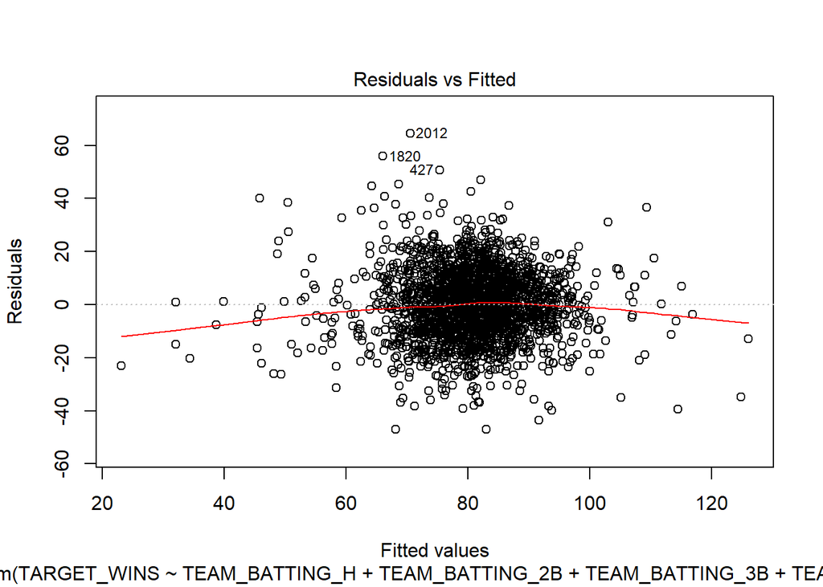

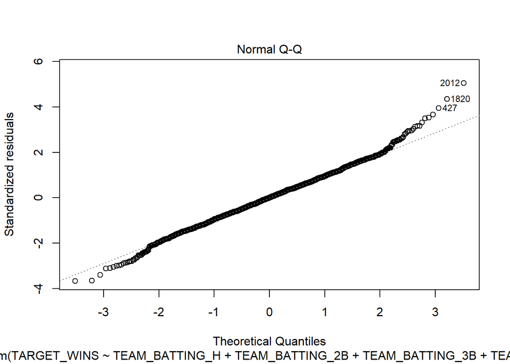

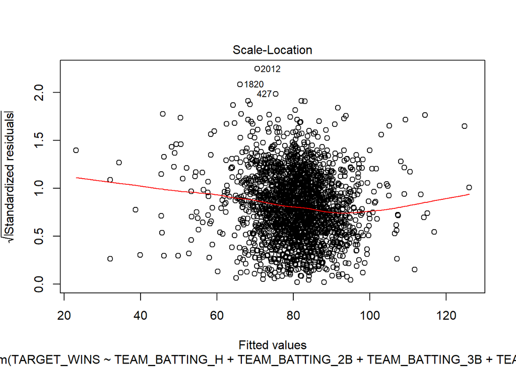

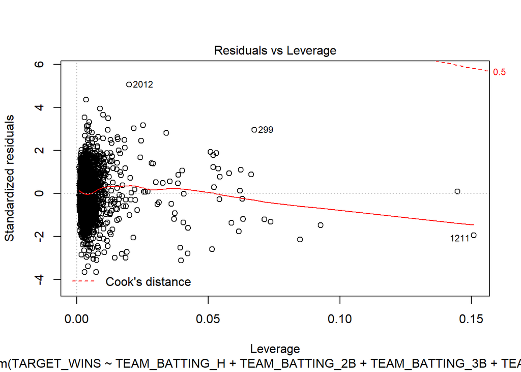

TEAM_FIELDING_E is withing the range 5-10 (suggesting co linearity with other variables), but eliminating TEAM_FIELDING_E does not improve the model. This yields our highest $R^2$ value with 40% of the variance explained by our model.

```
##
## Call:
## lm(formula = TARGET_WINS ~ TEAM_BATTING_H + TEAM_BATTING_2B +
##     TEAM_BATTING_3B + TEAM_BATTING_HR + TEAM_BATTING_BB + TEAM_BATTING_SO +
##     TEAM_BASERUN_SB + TEAM_PITCHING_H + TEAM_PITCHING_SO + TEAM_FIELDING_E +
##     TEAM_FIELDING_DP, data = moneyball_data)
##
## Residuals:
##     Min      1Q  Median      3Q     Max
## -32.317  -7.199   0.121   7.045  29.766
##
## Coefficients:
##                   Estimate Std. Error t value Pr(>|t|)
## (Intercept)      58.312951   6.019406   9.687  < 2e-16 ***
## TEAM_BATTING_H   -0.010007   0.010615  -0.943  0.34594
## TEAM_BATTING_2B  -0.049989   0.008875  -5.633 2.05e-08 ***
## TEAM_BATTING_3B   0.181788   0.018982   9.577  < 2e-16 ***
## TEAM_BATTING_HR   0.100845   0.009158  11.012  < 2e-16 ***
## TEAM_BATTING_BB   0.034055   0.003133  10.870  < 2e-16 ***
## TEAM_BATTING_SO   0.045928   0.016420   2.797  0.00521 **
## TEAM_BASERUN_SB   0.069889   0.005535  12.626  < 2e-16 ***
## TEAM_PITCHING_H   0.037438   0.009239   4.052 5.29e-05 ***
## TEAM_PITCHING_SO -0.065427   0.015514  -4.217 2.59e-05 ***
## TEAM_FIELDING_E  -0.116444   0.007029 -16.566  < 2e-16 ***
## TEAM_FIELDING_DP -0.112850   0.012279  -9.190  < 2e-16 ***
## ---
## Signif. codes:  0 '***' 0.001 '**' 0.01 '*' 0.05 '.' 0.1 ' ' 1
##
## Residual standard error: 10.19 on 1823 degrees of freedom
##   (441 observations deleted due to missingness)
## Multiple R-squared:  0.4045, Adjusted R-squared:  0.4009
## F-statistic: 112.6 on 11 and 1823 DF,  p-value: < 2.2e-16
```

# Part 4: Model Evaluation

```
##     1     2     3     4     5     6     7     8     9    10    11    12
## 19053 19819 23521 25909    NA    NA    NA 28254 22808 25989 26030 27311
##    13    14    15    16    17    18    19    20    21    22    23    24
## 25495 26555 24371 24507 21241 23984    NA 32912 28949 30107 27052 24929
##    25    26    27    28    29    30    31    32    33    34    35    36
## 25512 26358    NA 27375 29407 28038 29583 29170 27616 28192 24387 24435
##    37    38    39    40    41    42    43    44    45    46    47    48
## 23335 26508 40665 27287 25988 27142    NA    NA    NA    NA    NA 23915
##    49    50    51    52    53    54    55    56    57    58    59    60
## 23400 26645 27942 30557 22649 21948 23484 23999 33334 23194    NA    NA
##    61    62    63    64    65    66    67    68    69    70    71    72
## 32360 25743 25479 24397 23909    NA 28881 32844    NA 26929 30995 26664
##    73    74    75    76    77    78    79    80    81    82    83    84
## 26158 26493 26462 25813 24009 23308    NA    NA 30803 31162 34114 28234
##    85    86    87    88    89    90    91    92    93    94    95    96
```

[output cut: 29 more lines]

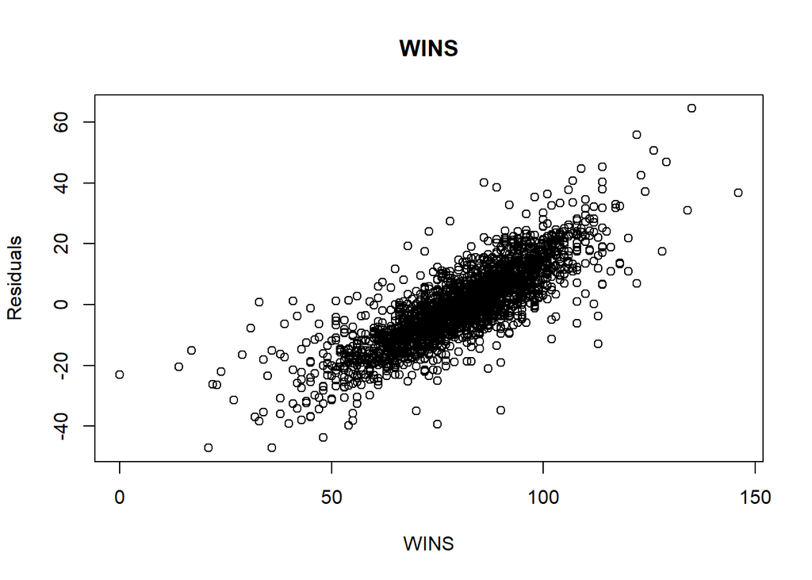